# Evolutionary Genomics Lab 3

## Data Analysis and Visualization in Python for Ecologists

The following lessons are from the [DataCarpentry](https://datacarpentry.org/python-ecology-lesson/) website. They include:

- Lesson 1: Starting with Data
- Lesson 2: Indexing, Slicing and Subsetting DataFrames in Python
- Lesson 3: Data Types and Formats
- Lesson 4: Combining DataFrames with Pandas
- Lesson 5: Data Workflows and Automation

### Lesson 1: Starting with Data

**Lesson Questions**

- How can I import data in Python?
- What is Pandas?
- Why should I use Pandas to work with data?

**Lesson Objectives**

- Navigate the workshop directory and download a dataset.
- Explain what a library is and what libraries are used for.
- Describe what the Python Data Analysis Library (Pandas) is.
- Load the Python Data Analysis Library (Pandas).
- Use read_csv to read tabular data into Python.
- Describe what a DataFrame is in Python.
- Access and summarize data stored in a DataFrame.
- Define indexing as it relates to data structures.
- Perform basic mathematical operations and summary statistics on data in a Pandas DataFrame.
- Create simple plots.

```python
# Set working directory

import os
os.chdir('/Users/greg/Box/courses/umass/fall-2020/evolutionary-genomics-and-bioinformatics/evo-geno-course/')
os.getcwd()
```

```
'/Users/greg/Box/courses/umass/fall-2020/evolutionary-genomics-and-bioinformatics/evo-geno-course'
```

#### Pandas in Python

```python
import pandas as pd
```

#### Reading CSV Data Using Panda

```python
surveys_df = pd.read_csv("data/lab-3-data/surveys.csv")
```

```python
surveys_df
```

|  | record_id | month | day | year | plot_id | species_id | sex | hindfoot_length | weight |
| --- | --- | --- | --- | --- | --- | --- | --- | --- | --- |
| 0 | 1 | 7 | 16 | 1977 | 2 | NL | M | 32.0 | NaN |
| 1 | 2 | 7 | 16 | 1977 | 3 | NL | M | 33.0 | NaN |
| 2 | 3 | 7 | 16 | 1977 | 2 | DM | F | 37.0 | NaN |
| 3 | 4 | 7 | 16 | 1977 | 7 | DM | M | 36.0 | NaN |
| 4 | 5 | 7 | 16 | 1977 | 3 | DM | M | 35.0 | NaN |
| ... | ... | ... | ... | ... | ... | ... | ... | ... | ... |
| 35544 | 35545 | 12 | 31 | 2002 | 15 | AH | NaN | NaN | NaN |
| 35545 | 35546 | 12 | 31 | 2002 | 15 | AH | NaN | NaN | NaN |
| 35546 | 35547 | 12 | 31 | 2002 | 10 | RM | F | 15.0 | 14.0 |
| 35547 | 35548 | 12 | 31 | 2002 | 7 | DO | M | 36.0 | 51.0 |
| 35548 | 35549 | 12 | 31 | 2002 | 5 | NaN | NaN | NaN | NaN |

35549 rows × 9 columns

```python
surveys_df.head() # The head() method displays the first several lines of a file
```

|  | record_id | month | day | year | plot_id | species_id | sex | hindfoot_length | weight |
| --- | --- | --- | --- | --- | --- | --- | --- | --- | --- |
| 0 | 1 | 7 | 16 | 1977 | 2 | NL | M | 32.0 | NaN |
| 1 | 2 | 7 | 16 | 1977 | 3 | NL | M | 33.0 | NaN |
| 2 | 3 | 7 | 16 | 1977 | 2 | DM | F | 37.0 | NaN |
| 3 | 4 | 7 | 16 | 1977 | 7 | DM | M | 36.0 | NaN |
| 4 | 5 | 7 | 16 | 1977 | 3 | DM | M | 35.0 | NaN |

#### Exploring Our Species Survey Data

```python
type(surveys_df)
```

```
pandas.core.frame.DataFrame
```

```python
surveys_df.dtypes # dtypes allows you to determine what kind of data are contained in your dataframe
```

```
record_id            int64
month                int64
day                  int64
year                 int64
plot_id              int64
species_id          object
sex                 object
hindfoot_length    float64
weight             float64
dtype: object
```

#### Useful Ways to View DataFrame objects in Python

**Challenge - DataFrames** Using our DataFrame surveys_df, try out the attributes & methods below to see what they return.

1. surveys_df.columns
2. surveys_df.shape Take note of the output of shape - what format does it return the shape of the DataFrame in? HINT: More on tuples [here](https://docs.python.org/3/tutorial/datastructures.html#tuples-and-sequences)
3. surveys_df.head( ) Also, what does surveys_df.head(15) do?
4. surveys_df.tail( )

```python
surveys_df.columns
```

```
Index(['record_id', 'month', 'day', 'year', 'plot_id', 'species_id', 'sex',
       'hindfoot_length', 'weight'],
      dtype='object')
```

```python
surveys_df.shape
# what format does the output return the shape of the DataFame in?
```

```
(35549, 9)
```

```python
surveys_df.head()
```

|  | record_id | month | day | year | plot_id | species_id | sex | hindfoot_length | weight |
| --- | --- | --- | --- | --- | --- | --- | --- | --- | --- |
| 0 | 1 | 7 | 16 | 1977 | 2 | NL | M | 32.0 | NaN |
| 1 | 2 | 7 | 16 | 1977 | 3 | NL | M | 33.0 | NaN |
| 2 | 3 | 7 | 16 | 1977 | 2 | DM | F | 37.0 | NaN |
| 3 | 4 | 7 | 16 | 1977 | 7 | DM | M | 36.0 | NaN |
| 4 | 5 | 7 | 16 | 1977 | 3 | DM | M | 35.0 | NaN |

```python
surveys_df.head(15)
```

|  | record_id | month | day | year | plot_id | species_id | sex | hindfoot_length | weight |
| --- | --- | --- | --- | --- | --- | --- | --- | --- | --- |
| 0 | 1 | 7 | 16 | 1977 | 2 | NL | M | 32.0 | NaN |
| 1 | 2 | 7 | 16 | 1977 | 3 | NL | M | 33.0 | NaN |
| 2 | 3 | 7 | 16 | 1977 | 2 | DM | F | 37.0 | NaN |
| 3 | 4 | 7 | 16 | 1977 | 7 | DM | M | 36.0 | NaN |
| 4 | 5 | 7 | 16 | 1977 | 3 | DM | M | 35.0 | NaN |
| 5 | 6 | 7 | 16 | 1977 | 1 | PF | M | 14.0 | NaN |
| 6 | 7 | 7 | 16 | 1977 | 2 | PE | F | NaN | NaN |
| 7 | 8 | 7 | 16 | 1977 | 1 | DM | M | 37.0 | NaN |
| 8 | 9 | 7 | 16 | 1977 | 1 | DM | F | 34.0 | NaN |
| 9 | 10 | 7 | 16 | 1977 | 6 | PF | F | 20.0 | NaN |
| 10 | 11 | 7 | 16 | 1977 | 5 | DS | F | 53.0 | NaN |
| 11 | 12 | 7 | 16 | 1977 | 7 | DM | M | 38.0 | NaN |
| 12 | 13 | 7 | 16 | 1977 | 3 | DM | M | 35.0 | NaN |
| 13 | 14 | 7 | 16 | 1977 | 8 | DM | NaN | NaN | NaN |
| 14 | 15 | 7 | 16 | 1977 | 6 | DM | F | 36.0 | NaN |

```python
surveys_df.tail()
```

|  | record_id | month | day | year | plot_id | species_id | sex | hindfoot_length | weight |
| --- | --- | --- | --- | --- | --- | --- | --- | --- | --- |
| 35544 | 35545 | 12 | 31 | 2002 | 15 | AH | NaN | NaN | NaN |
| 35545 | 35546 | 12 | 31 | 2002 | 15 | AH | NaN | NaN | NaN |
| 35546 | 35547 | 12 | 31 | 2002 | 10 | RM | F | 15.0 | 14.0 |
| 35547 | 35548 | 12 | 31 | 2002 | 7 | DO | M | 36.0 | 51.0 |
| 35548 | 35549 | 12 | 31 | 2002 | 5 | NaN | NaN | NaN | NaN |

#### Calculating Statistics from Data in a Pandas DataFrame

```python
surveys_df.columns
```

```
Index(['record_id', 'month', 'day', 'year', 'plot_id', 'species_id', 'sex',
       'hindfoot_length', 'weight'],
      dtype='object')
```

```python
pd.unique(surveys_df['species_id'])
```

```
array(['NL', 'DM', 'PF', 'PE', 'DS', 'PP', 'SH', 'OT', 'DO', 'OX', 'SS',
       'OL', 'RM', nan, 'SA', 'PM', 'AH', 'DX', 'AB', 'CB', 'CM', 'CQ',
       'RF', 'PC', 'PG', 'PH', 'PU', 'CV', 'UR', 'UP', 'ZL', 'UL', 'CS',
       'SC', 'BA', 'SF', 'RO', 'AS', 'SO', 'PI', 'ST', 'CU', 'SU', 'RX',
       'PB', 'PL', 'PX', 'CT', 'US'], dtype=object)
```

```python
pd.unique(surveys_df['plot_id'])
```

```
array([ 2,  3,  7,  1,  6,  5,  8,  4, 11, 14, 15, 13,  9, 10, 17, 16, 20,
       23, 18, 21, 22, 19, 12, 24])
```

**Challenge - Statistics**

1. Create a list of unique site ID’s (“plot_id”) found in the surveys data. Call it site_names. How many unique sites are there in the data? How many unique species are in the data?
2. What is the difference between len(site_names) and surveys_df['plot_id'].nunique()?

```python
surveys_df['plot_id'].nunique() # answer to question 1
```

```
24
```

```python
surveys_df['species_id'].nunique() # answer to question 2
```

```
48
```

#### Groups in Pandas

```python
surveys_df['weight'].describe()
```

```
count    32283.000000
mean        42.672428
std         36.631259
min          4.000000
25%         20.000000
50%         37.000000
75%         48.000000
max        280.000000
Name: weight, dtype: float64
```

```python
surveys_df['weight'].min()
```

```
4.0
```

```python
surveys_df['weight'].max()
```

```
280.0
```

```python
surveys_df['weight'].mean()
```

```
42.672428212991356
```

```python
surveys_df['weight'].std()
```

```
36.63125947458399
```

```python
surveys_df['weight'].count()
```

```
32283
```

```python
# Group Data by Sex
grouped_data = surveys_df.groupby('sex')
```

```python
# Summary statistics for all numeric columns by sex
grouped_data.describe()
```

| sex | record_id count | record_id mean | record_id std | record_id min | record_id 25% | record_id 50% | record_id 75% | record_id max | month count | month mean | ... | hindfoot_length 75% | hindfoot_length max | weight count | weight mean | weight std | weight min | weight 25% | weight 50% | weight 75% | weight max |
| --- | --- | --- | --- | --- | --- | --- | --- | --- | --- | --- | --- | --- | --- | --- | --- | --- | --- | --- | --- | --- | --- |
| F | 15690.0 | 18036.412046 | 10423.089000 | 3.0 | 8917.50 | 18075.5 | 27250.00 | 35547.0 | 15690.0 | 6.587253 | ... | 36.0 | 64.0 | 15303.0 | 42.170555 | 36.847958 | 4.0 | 20.0 | 34.0 | 46.0 | 274.0 |
| M | 17348.0 | 17754.835601 | 10132.203323 | 1.0 | 8969.75 | 17727.5 | 26454.25 | 35548.0 | 17348.0 | 6.396184 | ... | 36.0 | 58.0 | 16879.0 | 42.995379 | 36.184981 | 4.0 | 20.0 | 39.0 | 49.0 | 280.0 |

2 rows × 56 columns

```python
# Provide the mean for each numeric column by sex
grouped_data.mean()
```

| sex | record_id | month | day | year | plot_id | hindfoot_length | weight |
| --- | --- | --- | --- | --- | --- | --- | --- |
| F | 18036.412046 | 6.587253 | 15.880943 | 1990.644997 | 11.440854 | 28.836780 | 42.170555 |
| M | 17754.835601 | 6.396184 | 16.078799 | 1990.480401 | 11.098282 | 29.709578 | 42.995379 |

**Challenge - Summary Data**

1. How many recorded individuals are female and how many are male?
2. What happens when you group by two columns using the following syntax and then calculate mean values?
   - grouped_data2 = surveys_df.groupby(['plot_id', 'sex'])
   - grouped_data2.mean()
3. Summarize weight values for each site in your data.

```python
grouped_data['sex'].count() # Answer to question 1
```

```
sex
F    15690
M    17348
Name: sex, dtype: int64
```

```python
grouped_data2 = surveys_df.groupby(['plot_id', 'sex'])
grouped_data2.mean().head() # Answer to question 2
```

| plot_id | sex | record_id | month | day | year | hindfoot_length | weight |
| --- | --- | --- | --- | --- | --- | --- | --- |
| 1 | F | 18390.384434 | 6.597877 | 15.338443 | 1990.933962 | 31.733911 | 46.311138 |
|  | M | 17197.740639 | 6.121461 | 15.905936 | 1990.091324 | 34.302770 | 55.950560 |
| 2 | F | 17714.753608 | 6.426804 | 16.288660 | 1990.449485 | 30.161220 | 52.561845 |
|  | M | 18085.458042 | 6.340035 | 15.440559 | 1990.756119 | 30.353760 | 51.391382 |
| 3 | F | 19888.783875 | 6.610302 | 15.993281 | 1992.013438 | 23.774044 | 31.215349 |

```python
grouped_data3 = surveys_df.groupby('plot_id')
```

```python
grouped_data3['weight'].describe().head(10) # Answer to question 3
```

| plot_id | count | mean | std | min | 25% | 50% | 75% | max |
| --- | --- | --- | --- | --- | --- | --- | --- | --- |
| 1 | 1903.0 | 51.822911 | 38.176670 | 4.0 | 30.0 | 44.0 | 53.0 | 231.0 |
| 2 | 2074.0 | 52.251688 | 46.503602 | 5.0 | 24.0 | 41.0 | 50.0 | 278.0 |
| 3 | 1710.0 | 32.654386 | 35.641630 | 4.0 | 14.0 | 23.0 | 36.0 | 250.0 |
| 4 | 1866.0 | 47.928189 | 32.886598 | 4.0 | 30.0 | 43.0 | 50.0 | 200.0 |
| 5 | 1092.0 | 40.947802 | 34.086616 | 5.0 | 21.0 | 37.0 | 48.0 | 248.0 |
| 6 | 1463.0 | 36.738893 | 30.648310 | 5.0 | 18.0 | 30.0 | 45.0 | 243.0 |
| 7 | 638.0 | 20.663009 | 21.315325 | 4.0 | 11.0 | 17.0 | 23.0 | 235.0 |
| 8 | 1781.0 | 47.758001 | 33.192194 | 5.0 | 26.0 | 44.0 | 51.0 | 178.0 |
| 9 | 1811.0 | 51.432358 | 33.724726 | 6.0 | 36.0 | 45.0 | 50.0 | 275.0 |
| 10 | 279.0 | 18.541219 | 20.290806 | 4.0 | 10.0 | 12.0 | 21.0 | 237.0 |

#### Quickly Creating Summary Counts in Pandas

```python
species_counts = surveys_df.groupby('species_id')['record_id'].count().head()
print(species_counts)
```

```
species_id
AB    303
AH    437
AS      2
BA     46
CB     50
Name: record_id, dtype: int64
```

```python
surveys_df.groupby('species_id')['record_id'].count()['DO']
```

```
3027
```

**Challenge - Make a list** What's another way to create a list of species and associated *count* of the records in the data? Hint: you can perform count, min, etc. functions on groupby DataFrames in the same way you can perform them on regular DataFrames.

```python
surveys_df.groupby('species_id')['record_id'].count().head(10)
```

```
species_id
AB    303
AH    437
AS      2
BA     46
CB     50
CM     13
CQ     16
CS      1
CT      1
CU      1
Name: record_id, dtype: int64
```

#### Basic Math Functions

```python
# Multiply all weight values by 2
surveys_df['weight']*2
```

```
0          NaN
1          NaN
2          NaN
3          NaN
4          NaN
         ...
35544      NaN
35545      NaN
35546     28.0
35547    102.0
35548      NaN
Name: weight, Length: 35549, dtype: float64
```

#### Quick & Easy Plotting Data Using Pandas

[figure not shown]

```python
# Make sure figures appear inline in Jupyter Notebook
%matplotlib inline
# Create a quick bar chart
species_counts.plot(kind='bar')
```

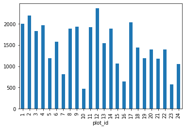

```python
total_count = surveys_df.groupby('plot_id')['record_id'].nunique()
total_count.plot(kind='bar')
```

**Challenge - Plots**

1. Create a plot of average weight across all species per site.
2. Create a plot of total males versus total females for an entire dataset.

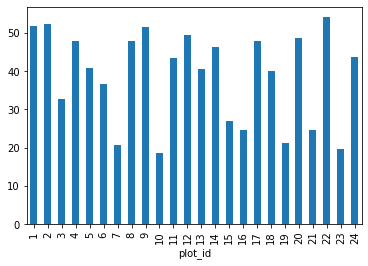

```python
ave_weight_per_site = surveys_df.groupby('plot_id')['weight'].mean()
ave_weight_per_site.plot(kind='bar')
```

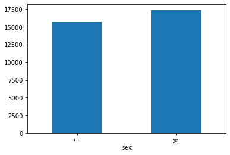

```python
total_sex = surveys_df.groupby('sex')['sex'].count()
total_sex.plot(kind='bar')
```

**Summary Plotting Challenge** Create a stacked bar plot, with weight on the Y axis, and the stacked variable being sex. The plot should show total weight by sex for each site.

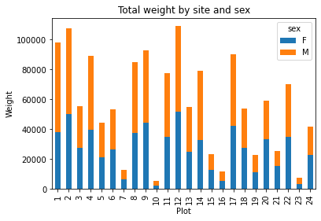

```python
stacked_by_sex = surveys_df.groupby(['plot_id', 'sex'])['weight'].sum().unstack()
plot = stacked_by_sex.plot.bar(stacked=True, title="Total weight by site and sex")
plot.set_ylabel("Weight")
plot.set_xlabel("Plot")
```

#### Key Points from Lesson 1: Starting with Data

- Libraries enable us to extend the functionality of Python.
- Pandas is a popular library for working with data.
- A Dataframe is a Pandas data structure that allows one to access data by column (name or index) or row.
- Aggregating data using the groupby() function enables you to generate useful summaries of data quickly.
- Plots can be created from DataFrames or subsets of data that have been generated with groupby().

### Lesson 2: Indexing, Slicing and Subsetting DataFrames in Python

**Lesson Questions**

- How can I access specific data within my data set?
- How can Python and Pandas help me to analyse my data?

**Lesson Objectives**

- Describe what 0-based indexing is.
- Manipulate and extract data using column headings and index locations.
- Employ slicing to select sets of data from a DataFrame.
- Employ label and integer-based indexing to select ranges of data in a dataframe.
- Reassign values within subsets of a DataFrame.
- Create a copy of a DataFrame.
- Query / select a subset of data using a set of criteria using the following operators: ==, !=, >, <, >=, <=.
- Locate subsets of data using masks.
- Describe BOOLEAN objects in Python and manipulate data using BOOLEANs.

```python
# Set working directory

import os
os.chdir('/Users/greg/Box/courses/umass/fall-2020/evolutionary-genomics-and-bioinformatics/evo-geno-course/')
os.getcwd()
```

```
'/Users/greg/Box/courses/umass/fall-2020/evolutionary-genomics-and-bioinformatics/evo-geno-course'
```

```python
import pandas as pd
```

```python
surveys_df = pd.read_csv("data/lab-3-data/surveys.csv")
```

#### Indexing and Slicing in Python

There are two ways to select a subset of a Python object:

```python
# Method 1: select a 'subset' of the data using the column name

surveys_df['species_id'].head(10)
```

```
0    NL
1    NL
2    DM
3    DM
4    DM
5    PF
6    PE
7    DM
8    DM
9    PF
Name: species_id, dtype: object
```

```python
# Method 2: use the column name as an 'attribute'; gives the same output

surveys_df.species_id.head(10)
```

```
0    NL
1    NL
2    DM
3    DM
4    DM
5    PF
6    PE
7    DM
8    DM
9    PF
Name: species_id, dtype: object
```

```python
# Creates an object, surveys_species, that only contains the `species_id` column

surveys_species = surveys_df['species_id']
surveys_species.head(10)
```

```
0    NL
1    NL
2    DM
3    DM
4    DM
5    PF
6    PE
7    DM
8    DM
9    PF
Name: species_id, dtype: object
```

```python
# Select the species and plot columns from the DataFrame

surveys_df[['species_id','plot_id']]
```

|  | species_id | plot_id |
| --- | --- | --- |
| 0 | NL | 2 |
| 1 | NL | 3 |
| 2 | DM | 2 |
| 3 | DM | 7 |
| 4 | DM | 3 |
| ... | ... | ... |
| 35544 | AH | 15 |
| 35545 | AH | 15 |
| 35546 | RM | 10 |
| 35547 | DO | 7 |
| 35548 | NaN | 5 |

35549 rows × 2 columns

```python
# What happens when you flip the order?

surveys_df[['plot_id','species_id']]
```

|  | plot_id | species_id |
| --- | --- | --- |
| 0 | 2 | NL |
| 1 | 3 | NL |
| 2 | 2 | DM |
| 3 | 7 | DM |
| 4 | 3 | DM |
| ... | ... | ... |
| 35544 | 15 | AH |
| 35545 | 15 | AH |
| 35546 | 10 | RM |
| 35547 | 7 | DO |
| 35548 | 5 | NaN |

35549 rows × 2 columns

```python
# What happens if you ask for a column that doesn't exist?
surveys_df['speciess']
```

[output not shown]

**Answer: an error occurs**

#### Extracting Range based Subsets: Slicing

```python
# Create a list of numbers
a = [1,2,3,4,5]
```

**Challenge - Extracting data**

1. What value does the following code return: a[0]
2. How about this code: a[5]
3. In the example above, calling a[5] returns an error. Why is that?
4. What about this code? a[len(a)]

```python
# What value does this code return?
a[0]
```

```
1
```

```python
# How about this code?
a[5]
```

```
---------------------------------------------------------------------------
IndexError                                Traceback (most recent call last)
<ipython-input-110-983ad28c29c5> in <module>
      1 # How about this code?
----> 2 a[5]

IndexError: list index out of range
```

**The above error occurs because there are not 6 digits in the list**

```python
# What about this code?
a[len(a)]
```

```
---------------------------------------------------------------------------
IndexError                                Traceback (most recent call last)
<ipython-input-25-1f95a32360be> in <module>
      1 # What about this code?
----> 2 a[len(a)]

IndexError: list index out of range
```

**Why is this error occurring? ...not exactly sure, but the following works:**

```python
len(a)
```

```
5
```

#### Slicing Subsets of Rows in Python

*Slicing using the **[ ]** operator selects a set of rows and/or columns from a DataFrame. To slice out a set of rows, you use the following syntax: **data[start:stop]**. When slicing in pandas the start bound is included in the output. The stop bound is one step BEYOND the row you want to select. So if you want to select rows 0, 1 and 2 your code would look like this:*

```python
# Select rows 0, 1, 2 (row 3 is not selected)
surveys_df[0:3]
```

|  | record_id | month | day | year | plot_id | species_id | sex | hindfoot_length | weight |
| --- | --- | --- | --- | --- | --- | --- | --- | --- | --- |
| 0 | 1 | 7 | 16 | 1977 | 2 | NL | M | 32.0 | NaN |
| 1 | 2 | 7 | 16 | 1977 | 3 | NL | M | 33.0 | NaN |
| 2 | 3 | 7 | 16 | 1977 | 2 | DM | F | 37.0 | NaN |

```python
# Select the first 5 rows
surveys_df[:5]
```

|  | record_id | month | day | year | plot_id | species_id | sex | hindfoot_length | weight |
| --- | --- | --- | --- | --- | --- | --- | --- | --- | --- |
| 0 | 1 | 7 | 16 | 1977 | 2 | NL | M | 32.0 | NaN |
| 1 | 2 | 7 | 16 | 1977 | 3 | NL | M | 33.0 | NaN |
| 2 | 3 | 7 | 16 | 1977 | 2 | DM | F | 37.0 | NaN |
| 3 | 4 | 7 | 16 | 1977 | 7 | DM | M | 36.0 | NaN |
| 4 | 5 | 7 | 16 | 1977 | 3 | DM | M | 35.0 | NaN |

```python
# Select the last element in the list
surveys_df[-1:]
```

|  | record_id | month | day | year | plot_id | species_id | sex | hindfoot_length | weight |
| --- | --- | --- | --- | --- | --- | --- | --- | --- | --- |
| 35548 | 35549 | 12 | 31 | 2002 | 5 | NaN | NaN | NaN | NaN |

#### Copying Objects vs. Referencing Objects in Python

```python
# Using the 'copy() method'
true_copy_surveys_df = surveys_df.copy()
```

```python
# Using the '=' operator
ref_surveys_df = surveys_df
```

*You might think that the code **ref_surveys_df = surveys_df** creates a fresh distinct copy of the surveys_df DataFrame object. However, using the **=** operator in the simple statement **y = x** does not create a copy of our DataFrame. Instead, **y = x** creates a new variable **y** that references the same object that **x** refers to. To state this another way, there is only one object (the DataFrame), and both **x** and **y** refer to it.*

*In contrast, the **copy()** method for a DataFrame creates a true copy of the DataFrame.*

```python
# Assign the value '0' to the first three rows of data in the DataFrame
ref_surveys_df[0:3] = 0
```

```python
# Reminder: ref_surveys_df was created using the '=' operator
ref_surveys_df.head()
```

|  | record_id | month | day | year | plot_id | species_id | sex | hindfoot_length | weight |
| --- | --- | --- | --- | --- | --- | --- | --- | --- | --- |
| 0 | 0 | 0 | 0 | 0 | 0 | 0 | 0 | 0.0 | 0.0 |
| 1 | 0 | 0 | 0 | 0 | 0 | 0 | 0 | 0.0 | 0.0 |
| 2 | 0 | 0 | 0 | 0 | 0 | 0 | 0 | 0.0 | 0.0 |
| 3 | 4 | 7 | 16 | 1977 | 7 | DM | M | 36.0 | NaN |
| 4 | 5 | 7 | 16 | 1977 | 3 | DM | M | 35.0 | NaN |

```python
surveys_df.head()
```

|  | record_id | month | day | year | plot_id | species_id | sex | hindfoot_length | weight |
| --- | --- | --- | --- | --- | --- | --- | --- | --- | --- |
| 0 | 0 | 0 | 0 | 0 | 0 | 0 | 0 | 0.0 | 0.0 |
| 1 | 0 | 0 | 0 | 0 | 0 | 0 | 0 | 0.0 | 0.0 |
| 2 | 0 | 0 | 0 | 0 | 0 | 0 | 0 | 0.0 | 0.0 |
| 3 | 4 | 7 | 16 | 1977 | 7 | DM | M | 36.0 | NaN |
| 4 | 5 | 7 | 16 | 1977 | 3 | DM | M | 35.0 | NaN |

```python
# Create brand new clean dataframe from original CSV file
surveys_df = pd.read_csv("data/lab-3-data/surveys.csv")
```

#### Slicing Subsets of Rows and Columns in Python

```python
# iloc[row slicing, column slicing]
surveys_df.iloc[0:3,1:4]
```

|  | month | day | year |
| --- | --- | --- | --- |
| 0 | 7 | 16 | 1977 |
| 1 | 7 | 16 | 1977 |
| 2 | 7 | 16 | 1977 |

```python
# Select all columns for rows of index values 0 and 10
surveys_df.loc[[0,10], :]
```

|  | record_id | month | day | year | plot_id | species_id | sex | hindfoot_length | weight |
| --- | --- | --- | --- | --- | --- | --- | --- | --- | --- |
| 0 | 1 | 7 | 16 | 1977 | 2 | NL | M | 32.0 | NaN |
| 10 | 11 | 7 | 16 | 1977 | 5 | DS | F | 53.0 | NaN |

```python
# What does this do?
surveys_df.loc[0, ['species_id', 'plot_id', 'weight']]
```

```
species_id     NL
plot_id         2
weight        NaN
Name: 0, dtype: object
```

```python
# What happens when type this code?
surveys_df.loc[[0, 10, 35549], :]
```

[output not shown]

**The Error occurs because the DataFrame ends at 35548**

```python
# Syntax for iloc indexing to finding a specific data element
# dat.iloc[row, column]
surveys_df.iloc[2, 6]
```

```
'F'
```

**Challenge - Range**

1. What happens when you execute:
   - surveys_df[0:1]
   - surveys_df[:4]
   - surveys_df[:-1]
2. What happens when you call:
   - surveys_df.iloc[0:4, 1:4]
   - surveys_df.loc[0:4, 1:4]

How are these two commands different?

```python
surveys_df[0:1]
```

|  | record_id | month | day | year | plot_id | species_id | sex | hindfoot_length | weight |
| --- | --- | --- | --- | --- | --- | --- | --- | --- | --- |
| 0 | 1 | 7 | 16 | 1977 | 2 | NL | M | 32.0 | NaN |

```python
surveys_df[:4]
```

|  | record_id | month | day | year | plot_id | species_id | sex | hindfoot_length | weight |
| --- | --- | --- | --- | --- | --- | --- | --- | --- | --- |
| 0 | 1 | 7 | 16 | 1977 | 2 | NL | M | 32.0 | NaN |
| 1 | 2 | 7 | 16 | 1977 | 3 | NL | M | 33.0 | NaN |
| 2 | 3 | 7 | 16 | 1977 | 2 | DM | F | 37.0 | NaN |
| 3 | 4 | 7 | 16 | 1977 | 7 | DM | M | 36.0 | NaN |

```python
surveys_df[:-1]
```

|  | record_id | month | day | year | plot_id | species_id | sex | hindfoot_length | weight |
| --- | --- | --- | --- | --- | --- | --- | --- | --- | --- |
| 0 | 1 | 7 | 16 | 1977 | 2 | NL | M | 32.0 | NaN |
| 1 | 2 | 7 | 16 | 1977 | 3 | NL | M | 33.0 | NaN |
| 2 | 3 | 7 | 16 | 1977 | 2 | DM | F | 37.0 | NaN |
| 3 | 4 | 7 | 16 | 1977 | 7 | DM | M | 36.0 | NaN |
| 4 | 5 | 7 | 16 | 1977 | 3 | DM | M | 35.0 | NaN |
| ... | ... | ... | ... | ... | ... | ... | ... | ... | ... |
| 35543 | 35544 | 12 | 31 | 2002 | 15 | US | NaN | NaN | NaN |
| 35544 | 35545 | 12 | 31 | 2002 | 15 | AH | NaN | NaN | NaN |
| 35545 | 35546 | 12 | 31 | 2002 | 15 | AH | NaN | NaN | NaN |
| 35546 | 35547 | 12 | 31 | 2002 | 10 | RM | F | 15.0 | 14.0 |
| 35547 | 35548 | 12 | 31 | 2002 | 7 | DO | M | 36.0 | 51.0 |

35548 rows × 9 columns

```python
surveys_df.iloc[0:4, 1:4]
```

|  | month | day | year |
| --- | --- | --- | --- |
| 0 | 7 | 16 | 1977 |
| 1 | 7 | 16 | 1977 |
| 2 | 7 | 16 | 1977 |
| 3 | 7 | 16 | 1977 |

```python
surveys_df.loc[0:4, 1:4]
```

[output not shown]

[output cut: 14 more lines]

[output not shown]